# Lecture 18: Multinomial Classification with Keras and ELS:2002

## Variable Importance

Keras models do not have interpretable coefficients — there is no `coef()` method. This is the tradeoff for the nonlinearity. We recover feature importance via **permutation**: for each predictor, we shuffle its values across all observations, generate new predictions, and measure how much the model’s macro-weighted ROC AUC drops. A large drop means the model relied heavily on that feature.

**Permutation importance** is the standard approach for interpreting models — like neural networks — that have no coefficients to read off directly.

The core idea is to ask: *how much does the model’s performance degrade when it can no longer use a particular feature?* We operationalize this by destroying the feature’s information content without changing the shape of the data. Rather than removing the column entirely (which would break the model’s input dimensions), we shuffle its values randomly across all observations. This severs the relationship between that feature and the outcome while leaving everything else intact.

Concretely, for each predictor we:

1. Start with a **baseline** — run the fitted model on a held-out sample and record its macro-weighted ROC AUC. This is the model’s performance when it has full access to all features.
2. **Permute** — randomly reorder the values of one predictor column, so that each student now has some other student’s value for that variable. The model still sees a number in that column; it just no longer carries real information about that student.
3. **Re-score** — run the model again on the permuted data and record the new AUC.
4. **Importance = baseline AUC − permuted AUC.** If the feature mattered, the model’s ability to rank students by their true major deteriorates noticeably. If the feature was irrelevant or redundant, the AUC barely changes.

We repeat steps 2–4 five times (`nsim = 5`) for each feature and average the drops, because any single shuffle is one random draw — averaging over several gives a more stable estimate.

**Why ROC AUC specifically?** Because our outcome is multinomial and imbalanced. Accuracy would be dominated by the most common major categories. Macro-weighted AUC evaluates the model’s ability to discriminate each class from all others, weighted by class frequency, so every major field contributes to the score roughly in proportion to how many students are in it.

**Why a 75% sample rather than the full training set?** Purely for speed — we are running hundreds of predict calls (one per feature per simulation). The 75% sample is drawn once and held fixed across all permutations so that the baseline and every permuted AUC are computed on exactly the same rows, making the differences comparable.

**What the numbers mean:** An importance of 0.03 means permuting that feature caused macro-weighted AUC to drop by about 3 percentage points on average. A feature near zero had essentially no effect when scrambled — either the model wasn’t using it, or its information was fully recoverable from correlated predictors that remained intact.

`vip::vi_permute()` does not support multiclass probability metrics — its `metric` argument passes vectors to a scalar function, but `roc_auc_vec()` for multiclass requires a full probability matrix. We therefore implement the loop directly, which is only slightly more code and makes the algorithm completely transparent.

The logic is:

1. Get a baseline AUC on a 75% sample of the training data.
2. For each predictor column, shuffle its values (breaking the predictor-outcome association), predict, compute AUC, and record the drop from baseline.
3. Repeat `nsim` times and average the drops.

```r
# Compute macro-weighted ROC AUC from a fitted workflow and a data frame.
# Returns a single scalar.
compute_auc <- function(fitted_wf, data) {
  probs <- predict(fitted_wf, data, type = "prob")
  truth <- data[["cip2"]]

  bind_cols(probs, tibble(cip2 = truth)) %>%
    roc_auc(
      truth     = cip2,
      matches("^\\.pred_"),       # <-- regex match works inside functions
      estimator = "macro_weighted"
    ) %>%
    pull(.estimate)
}
# Permutation importance for a single predictor column.
# Returns the mean AUC drop across nsim permutations.
permute_one <- function(fitted_wf, data, col, nsim) {
  map_dbl(seq_len(nsim), function(i) {
    permuted <- data %>%
      mutate(across(all_of(col), sample))
    baseline_auc - compute_auc(fitted_wf, permuted)
  }) %>%
    mean()
}
```

```r
# Pull the raw prob matrix once per permutation at the top level,
# rather than calling predict() inside a helper function.

set.seed(2002)
vip_sample <- els_train %>% slice_sample(prop = 0.75)

# Baseline: predict once at top level, score it
baseline_probs <- augment(fitted_wf, vip_sample)
```

```
## 91/91 - 0s - 33ms/epoch - 366us/step
## 91/91 - 0s - 31ms/epoch - 340us/step
```

```r
score_auc <- function(df) {
  df %>%
    roc_auc(
      truth     = cip2,
      matches("^\\.pred_(?!class)",perl=TRUE),
      estimator = "macro_weighted"
    ) %>%
    pull(.estimate)
}

baseline_auc <- score_auc(baseline_probs)
cat("Baseline AUC:", round(baseline_auc, 4), "\n")
```

```
## Baseline AUC: 0.6071
```

```r
pred_cols <- names(baseline_probs) %>% keep(~ startsWith(.x, ".pred_"))
non_pred_cols <- c(
  "cip2", "stu_id", "bysex", "byrace",
  "f3tzbch1cip2", "cip2_collapsed_code", "cip2_collapsed_label",
  ".pred_class", pred_cols
)
pred_features <- setdiff(names(vip_sample), non_pred_cols)

# For each feature: permute in vip_sample, re-augment at top level, score
permute_one <- function(col, nsim = 5) {
  map_dbl(seq_len(nsim), function(i) {
    permuted_data <- vip_sample %>%
      mutate(across(all_of(col), sample))
    permuted_probs <- augment(fitted_wf, permuted_data)
    baseline_auc - score_auc(permuted_probs)
  }) %>% mean()
}

vip_scores <- tibble(Variable = pred_features) %>%
  mutate(Importance = map_dbl(Variable, permute_one)) %>%
  arrange(desc(Importance))
```

[output not shown]

[output cut: 665 more lines]

[output not shown]

```r
write_rds(vip_scores,file=here("scripts","vip_scores.rds"))
```

```r
vip_scores <- readRDS(here("scripts","vip_scores.rds"))
```

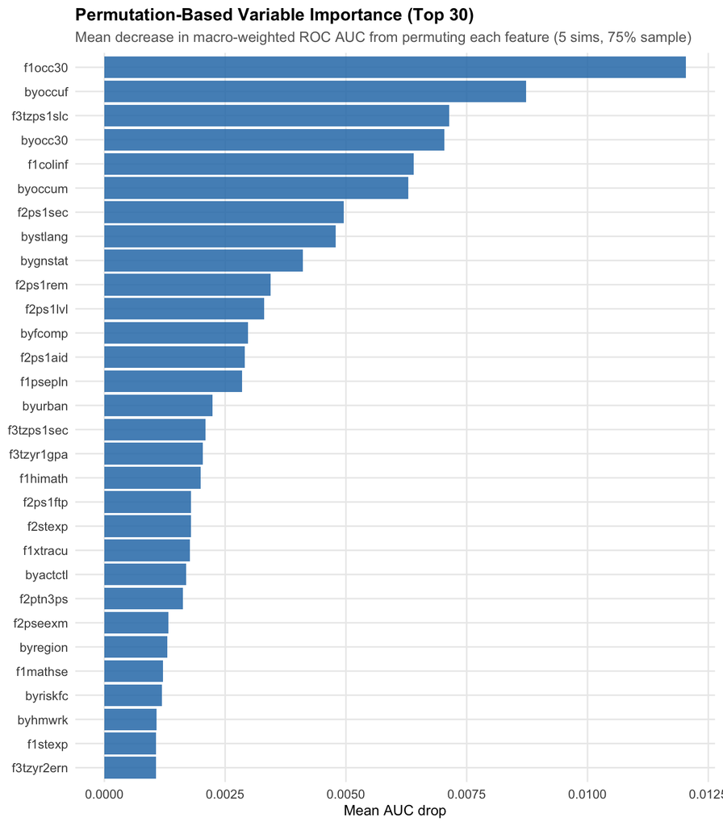

```r
vip_scores %>%
  slice_max(Importance, n = 30) %>%
  mutate(Variable = fct_reorder(Variable, Importance)) %>%
  ggplot(aes(x = Importance, y = Variable)) +
  geom_col(fill = "#2C7BB6", alpha = 0.85) +
  labs(
    title    = "Permutation-Based Variable Importance (Top 30)",
    subtitle = "Mean decrease in macro-weighted ROC AUC from permuting each feature (5 sims, 75% sample)",
    x        = "Mean AUC drop",
    y        = NULL
  ) +
  theme_els()
```

**Caveats to keep in mind:**

- Correlated features *understate* individual importance — if `bytxmstd` and `bytxrstd` are correlated, permuting one still leaves the other intact, so the model can partially recover. This leads to each appearing less important than they collectively are.
- Importance reflects *model reliance*, not causal effect. A feature the model uses heavily might have that relationship for reasons specific to this dataset or this architecture.
- Scores are post-hoc and specific to this fitted model. A different model with different hyperparameters could produce a somewhat different importance ranking.

## Keras vs. PyTorch: A Summary

Here is a consolidated comparison of the features we used today, with their PyTorch equivalents:

| Feature | Keras | PyTorch |
| --- | --- | --- |
| Early stopping | `callback_early_stopping()` in `set_engine()` | Write your own loop logic or use Lightning |
| Validation split | `validation_split = 0.2` argument | Split `DataLoader` manually |
| Learning rate scheduling | `callback_reduce_lr_on_plateau()` | `torch.optim.lr_scheduler.*` |
| Training history | Returned automatically from `fit()` | Append to list in training loop |
| TensorBoard logging | `callback_tensorboard()` | `torch.utils.tensorboard.SummaryWriter` |
| Model checkpointing | `callback_model_checkpoint()` | Manual `torch.save()` in loop |
| Softmax + cross-entropy output | Automatic for multiclass | Specify `nn.Softmax` + `nn.CrossEntropyLoss` explicitly |

The pattern is consistent: Keras externalizes infrastructure that PyTorch internalizes. Keras is narrower but faster to stand up; PyTorch is more expressive but requires more code. For applied research where model architecture is standard and the domain problem is the hard part, Keras’s defaults often get you where you need to go.

## Next Steps

In the next lecture we will take the fitted model and use it for **subgroup analysis** by race and gender — the variables we deliberately withheld from the predictor set. We will look at whether the model’s errors are distributed evenly across groups or concentrated in particular subpopulations, and discuss what that means for questions of algorithmic fairness in educational contexts.